# Lab 2: Cats vs Dogs

### Part (f) - 5pt

How does the your best CNN model compare with an 2-layer ANN model (no convolutional layers) on classifying cat and dog images. You can use a 2-layer ANN architecture similar to what you used in Lab 1. You should explore different hyperparameter settings to determine how well you can do on the validation dataset. Once satisified with the performance, you may test it out on the test data.

Hint: The ANN in lab 1 was applied on greyscale images. The cat and dog images are colour (RGB) and so you will need to flatted and concatinate all three colour layers before feeding them into an ANN.

```
Files already downloaded and verified
Files already downloaded and verified
Epoch 1: Train err: 0.486625, Train loss: 0.6933326029008434 |Validation err: 0.455, Validation loss: 0.6879132390022278
Epoch 2: Train err: 0.427125, Train loss: 0.67939692735672 |Validation err: 0.412, Validation loss: 0.6769351065158844
Epoch 3: Train err: 0.41125, Train loss: 0.6718621023239628 |Validation err: 0.407, Validation loss: 0.6715616956353188
Epoch 4: Train err: 0.40275, Train loss: 0.665788181366459 |Validation err: 0.409, Validation loss: 0.6658869609236717
Epoch 5: Train err: 0.397625, Train loss: 0.6621389600538439 |Validation err: 0.407, Validation loss: 0.6638624146580696
Epoch 6: Train err: 0.39575, Train loss: 0.6603204531054343 |Validation err: 0.4095, Validation loss: 0.663334883749485
Epoch 7: Train err: 0.392625, Train loss: 0.6571945086602242 |Validation err: 0.4045, Validation loss: 0.6622826680541039
Epoch 8: Train err: 0.38975, Train loss: 0.6557257809946614 |Validation err: 0.403, Validation loss: 0.6593106985092163
Epoch 9: Train err: 0.38775, Train loss: 0.6536499377219908 |Validation err: 0.4025, Validation loss: 0.6567518338561058
Epoch 10: Train err: 0.384875, Train loss: 0.6531144842024772 |Validation err: 0.4055, Validation loss: 0.6567492932081223
Epoch 11: Train err: 0.38225, Train loss: 0.6497075615390655 |Validation err: 0.401, Validation loss: 0.65633824467659
Epoch 12: Train err: 0.381375, Train loss: 0.647529746255567 |Validation err: 0.398, Validation loss: 0.6549452543258667
Epoch 13: Train err: 0.377625, Train loss: 0.6489002916120714 |Validation err: 0.395, Validation loss: 0.6539705023169518
Epoch 14: Train err: 0.377875, Train loss: 0.6451720922223984 |Validation err: 0.3965, Validation loss: 0.6561417356133461
Epoch 15: Train err: 0.375375, Train loss: 0.6444370554339501 |Validation err: 0.394, Validation loss: 0.6527101024985313
Epoch 16: Train err: 0.375875, Train loss: 0.6433041980189662 |Validation err: 0.391, Validation loss: 0.6525653228163719
Epoch 17: Train err: 0.3745, Train loss: 0.6421823386223086 |Validation err: 0.3905, Validation loss: 0.6518913432955742
Epoch 18: Train err: 0.371375, Train loss: 0.6408840014088538 |Validation err: 0.39, Validation loss: 0.6522262990474701
Epoch 19: Train err: 0.372875, Train loss: 0.6390952910146406 |Validation err: 0.3905, Validation loss: 0.649550274014473
Epoch 20: Train err: 0.371625, Train loss: 0.638811876696925 |Validation err: 0.3845, Validation loss: 0.6512059643864632
Epoch 21: Train err: 0.371, Train loss: 0.6378232529086452 |Validation err: 0.3825, Validation loss: 0.6510981246829033
Epoch 22: Train err: 0.367625, Train loss: 0.63719029003574 |Validation err: 0.389, Validation loss: 0.6489558294415474
Epoch 23: Train err: 0.36675, Train loss: 0.6368980119305272 |Validation err: 0.3835, Validation loss: 0.6490115523338318
Epoch 24: Train err: 0.36475, Train loss: 0.6340390193846918 |Validation err: 0.382, Validation loss: 0.6507077440619469
Epoch 25: Train err: 0.3615, Train loss: 0.6326327285458965 |Validation err: 0.384, Validation loss: 0.6483332812786102
Epoch 26: Train err: 0.36325, Train loss: 0.6310545417570299 |Validation err: 0.379, Validation loss: 0.6490855365991592
Epoch 27: Train err: 0.359, Train loss: 0.6313030085256023 |Validation err: 0.3825, Validation loss: 0.6488847956061363
Epoch 28: Train err: 0.358375, Train loss: 0.6301331750808223 |Validation err: 0.383, Validation loss: 0.6480538547039032
Epoch 29: Train err: 0.3575, Train loss: 0.6278889813730794 |Validation err: 0.382, Validation loss: 0.646805614233017
Epoch 30: Train err: 0.355125, Train loss: 0.627836617731279 |Validation err: 0.382, Validation loss: 0.6492830440402031
Finished Training
Total time elapsed: 119.40 seconds
```

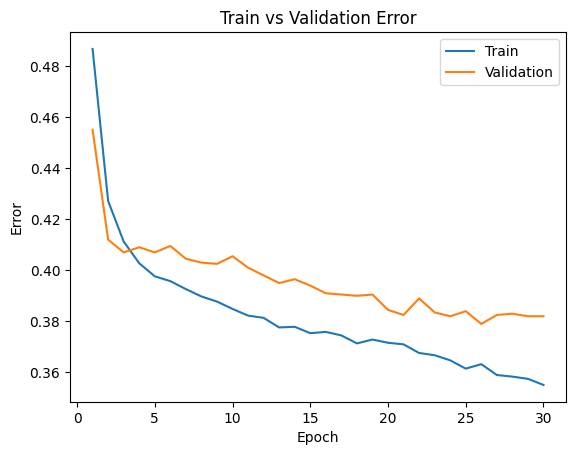

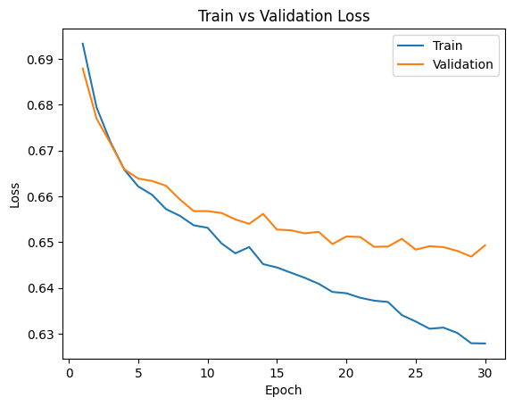

```python
class Pigeon(nn.Module):
    def __init__(self):
        super(Pigeon, self).__init__()
        self.layer1 = nn.Linear(32 * 32 * 3, 30)
        self.layer2 = nn.Linear(30, 1)
        self.name = 'ANN'
    def forward(self, img):
        flattened = img.view(-1, 32 * 32 * 3)
        activation1 = self.layer1(flattened)
        activation1 = F.relu(activation1)
        activation2 = self.layer2(activation1)
        activation2 = activation2.squeeze(1)
        return activation2

pigeon = Pigeon()

#Training
train_net(pigeon, batch_size = 264, learning_rate = 0.001)
pigeon_path = get_model_name("ANN", batch_size = 264, learning_rate= 0.001, epoch = 29)
plot_training_curve(pigeon_path)
```

```python
train_loader, val_loader, test_loader, classes = get_data_loader(
    target_classes=["cat", "dog"],
    batch_size=128)
net = pigeon
criterion = nn.BCEWithLogitsLoss()
error, loss = evaluate(net, test_loader, criterion)
print('The test classification error is:', error)
print('The test classfication loss is:',loss)

#Compared to the CNN network, ANN has a much lower
#accuracy in classfiying cats and dogs.
#It has a test classification error of 0.37, and a
#test loss of 0.64. Therefore, using an ANN model,
#only flattening the image will lose many important
#distinguishing features for cats and dogs, whereas
# a CNN network will capture both low level and high
#level features in cats and dogs for more accurate
#classification.
```

```
Files already downloaded and verified
Files already downloaded and verified
The test classification error is: 0.37
The test classfication loss is: 0.6419178508222103
```